# BM05BAM–2023 Group Project Part 1

Compiled 2023-11-21 11:59:50.804038

# Overview

Scheduling classrooms at RSM is a challenge, due to growing student numbers and a fixed number of classrooms. Allocation of classrooms to the core MSc courses begins on March 15, when the eventual number of enrolled students is highly uncertain. In order to begin planning, the scheduling team relies on predictions for the number of enrolled students in each MSc program. These predictions are currently made using simple heuristics.

Your task is to make good predictions using tools from this course and data provided by the admissions team. These data describe enrollment offers for the academic years 2020/21–2023/24. You will use the first three years of data (2020/21–AY2022/23) to tune, select, and assess a predictive model. You will then retrain this model in order to predict enrollment for the 2023/24 academic year for each MSc program.

Based on these efforts, your team will produce two main deliverables:

- A recorded presentation describing your main findings and recommendations
- A supporting document (R script or R markdown file) that can be used to reproduce all of the results in your presentation

# Tasks

Your team is expected to do the following:

1. **Data splitting:** Determine which subsets of the data to use for analysis, assessment, and final training of the model
   - Because your models will be trained on data from one time period in order to predict observations in another, splitting the data will not be as straightforward as in the Tutorials
   - A companion document, *BM05BAM–2023 Group Project Part 2*, provides details on dividing the data into analysis, assessment, final training, and prediction sets
2. **Data exploration:** Explore the data to understand it better, and to identify any feature engineering that will improve your models
3. **Assessment metrics:** Choose an appropriate set of metrics for tuning, assessing, and selecting among candidate models, based on your understanding of the problem
   - What counts as a good prediction in this context is unclear, and you will need to bring clarity to this issue
   - Your team must decide whether over-predicting (making poor use of larger rooms) or under-predicting (not providing enough space for all students) is worse—or if they are equally bad
   - You will need to choose a primary (i.e. most important) evaluation metric reflecting this decision, and construct and assess your models accordingly
4. **Multiple methods:** Use a variety of supervised learning methods from the course. At a minimum, you must consider at least one model from each of these two groups:
   - **Group A**: k-nearest neighbors, regularized logistic regression
   - **Group B:** Random forest, boosting
5. **Model selection and assessment:** Select a final model and assess its performance against an appropriate test set
6. **Make predictions:** Retrain the final model, generate predictions for AY2023, and submit these predictions (along with your chosen metric for assessing prediction quality) as an interim deliverable
   - Initially, to prevent data leakage, the prediction set will not contain the target variable for AY2023
   - Before the final deadline, you will submit your final predictions and your primary evaluation metric
   - Afterward, you will gain access to the full data, so you can assess the final model’s true performance against the AY2023 data and finalize your presentation
   - In both your interim and final predictions, you must report, for each program, the average predicted probability of enrollment (soft predictions), and the predicted number of attending students (hard predictions), for the subset of AY2023 offers sent out prior to March 15
   - To produce hard predictions, you must select a suitable decision threshold
7. **Evaluate predictions:** Compare the final model’s performance against the full AY2023 data based on the primary metric (among others), and perform an error analysis
8. **Presentation:** Present your results in a recorded presentation of no more than 10 minutes
9. **Reproducible code:** Document all of the aforementioned steps in a well-commented and reproducible (by me) R script or R markdown file; all results in your presentation need to be reproducible from this code
10. **Work as a team:** You should strive to work together well and allocate the workload as fairly and efficiently as you can

Tasks 8–10 are explained in more detail next.

**Presentation**

The recorded presentation is your team’s main deliverable. Your presentation should include the following:

1. A brief summary of the problem and your goals
2. A discussion of your team’s choices about how to use the data
3. A discussion of any features in the data that you expected—prior to building your models—would be especially relevant to the problem
4. An overview of your candidate models
5. A discussion of the primary metric your team chose to measure prediction quality (and why you chose it)
6. A brief description of the main aspects of your final model
7. Your final predictions, as well as an assessment of those predictions in terms of the primary metric you chose (and other metrics if appropriate), and a brief explanation of how you chose the decision threshold for hard predictions
8. A discussion of any features that were especially important for making predictions
9. Recommendations for how to further improve predictions in 2024 based on an error analysis

You have considerable freedom in how you choose to convey all of this information in a recorded presentation. If you do not know where to start, I suggest creating a slide deck and writing a voice-over script, which one of you can read out loud while advancing through the slides. But note that there is no real requirement to use slides. You should of course put information on the screen, otherwise your presentation will not be very clear, but you don’t have to present that information using a slide deck. You can elect the best speaker in your group to narrate the presentation, or you can all take turns; it’s up to you.

The substance of your presentation is more important than its style. *As long as I can understand what you are saying and can read whatever you choose to show on the screen*, I am not very concerned about the production quality of your recording (this is *not* a course on how to become a data science YouTuber). If you find it difficult to use dedicated screen- and voice-recording software, consider setting up a (recorded) Zoom call within your group, sharing the slides, and reading through the script. These recordings can be quite good.

You will upload the presentation to the assignment folder under the Panopto Video tab on Canvas. I will show you how to do this during class.

**Reproducible code**

A secondary deliverable from your team is an R script or R markdown file containing your analysis. All of the results presented in your presentation—all numbers, tables, and graphs—should be generated from code contained in this script. I will attempt to reproduce your results, and if I am unable to do so, it will negatively impact your team’s final grade. If your code is well organized and clearly commented or annotated, that will positively impact your team’s grade.

You will submit your supplementary documents via a Canvas assignment.

**Work as a team**

You should try to allocate the workload in a way that seems fair to everyone on your team. If you experience conflicts within your team, I would like you to resolve them on your own. As a *last resort,* you can involve me to help mediate any otherwise unresolvable conflicts.

After submitting your presentation and code, you will be required to rate yourself and your team members in terms of their contribution to the project. These ratings will not be shared with the other team members.

Points will be deducted from your individual score if you do not submit your ratings. However, other than that, *I have no plans to incorporate the ratings into your grade.* I am collecting these ratings so that I can gain a sense of how workload is shared among team members, on average, and how well team members’ ratings line up with each other. Also, if the measures are of high enough quality, I may incorporate them into how this assignment is graded *in the future.* But before I do that, I need to understand what these ratings look like. To reiterate: I do not plan to adjust your grade based on these ratings.

Having said that, in the event that the ratings reveal the possibility of a *massive* disparity in contribution within a team, I may reach out to your team to investigate it further. If the situation warrants it, I may adjust the grades of individual team members in accordance with what I discover. However, any such adjustments would not be based directly on the ratings data, but instead on what I learn by talking to your group.

**More about the ratings**

These are the questions you will need to answer:

1. Compared to the average effort put in by the other group members, how much effort did this member put in?
2. Compared to the average amount of time put in by the other group members, how much time did this member put in?
3. Consider only contributions that had a positive impact on the final submission. Compared to the average contribution made by the other group members, how much of a positive contribution did this member make?
4. If the group’s grade on the final submission were to be divided among members based on their overall contribution, so that some members might get a higher grade and others a lower grade, what should this group member’s grade be?

For these three questions, the possible responses are: “Member put in no effort/time/contribution”, “About 50% less”, “About 25% less”, “About equal effort/time/contribution”, “About 25% more”, and “About 50% more.” For the last question, the possible responses are: “Member did not contribute to the project”, and 6 options of the form “Member’s grade should be $X$ [of] the group’s—if the final submission earns $8/10$, the member should receive a grade of $Y$,” with options for $(X,Y) \in \{(50\%, 4/10),$ $(75\%, 6/10),$ $(90\%, 7.2/10),$ $(\text{the same as}, 8/10),$ $(110\%, 8.8/10),$ $(125\%, 10/10)\}$.

# Grading rubric

I will use the following grading rubric shown in the table below to assess your work. The columns labeled “Criteria” and “Mastery,” explain what I expect in terms of your performance.

[output not shown]

There are ten criteria listed in the table above. I will qualitatively assess your team’s performance on each criterion (e.g., Mastery, Developing, etc.), and assign a point value within the given range. I will then sum the points awarded across all ten criteria (thus giving equal weight to each).

Your team’s point total is mapped to your grade so that 625 points = 5.5/10 and 1000 points = 8/10, with grades linearly interpolated for all values between 625 ad 1000. Although a maximum of 1250 points is possible, only 1200 point are needed to earn 10/10. Grades are linearly interpolated for values between 1200 = 10/10 and 1000 = 8/10.

The following table shows the *minimum* points needed to obtain different grades, and the plot depicts the same information.

| Grade | Minimum Points |
| --- | --- |
| 10 | 1200 |
| 9.5 | 1150 |
| 9 | 1100 |
| 8.5 | 1050 |
| 8 | 1000 |
| 7.5 | 925 |
| 7 | 850 |
| 6.5 | 775 |
| 6 | 700 |
| 5.5 | 625 |

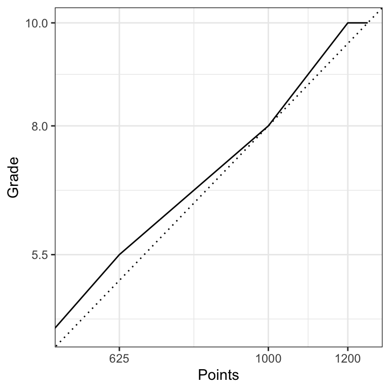

**More about the mapping from points to grades**

In the plot, the dashed line is a straight line connecting runs from 0 points = 0/10 with 1250 points = 10/10, which is what a simple linear mapping of points to grades would suggest. I have made two changes from this simple mapping, while keeping the 8/10 = 1000 point a constant.

The first change is to lower the number of points needed to earn a passing grade of 5.5/10. Only 625 are needed, instead of 687.5. The second change is to lower the number of points needed to earn 10/10. Only 1200 are needed, instead of 1250. Notice that above 1000 points, additional points increase your grade at a higher rate than they do below 1000 points. A team that earns 1000 points has done a great job, basically achieving everything I hoped they would. The little kick up above 1000 points is hopefully an incentive for you to look for little ways to do even more than what is expected, and make me even happier.